# Machine Learning / Aprendizagem Automática

```
total: 192
```

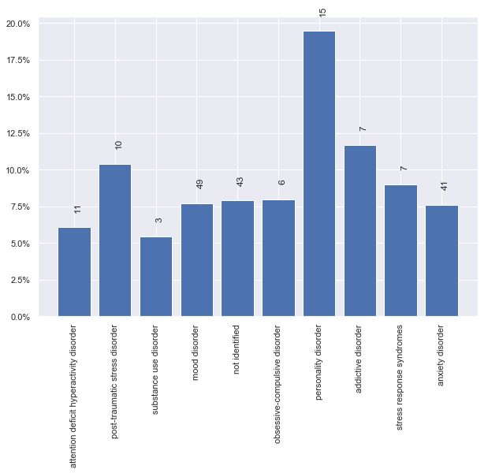

```
total: 262
```

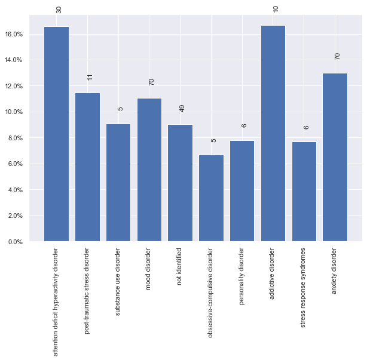

```
total: 511
```

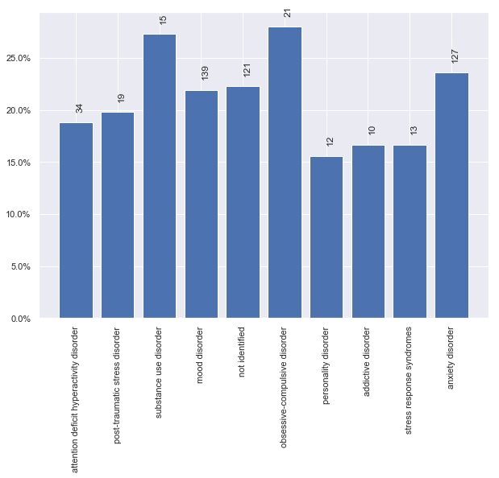

```
total: 372
```

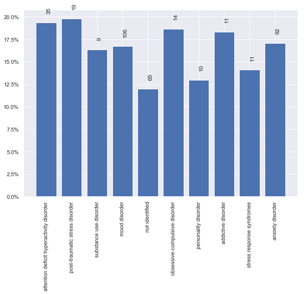

```
total: 89
```

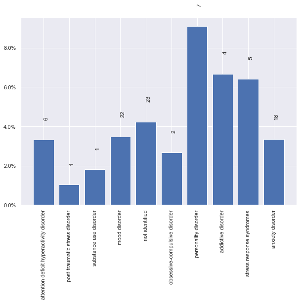

```
total: 184
```

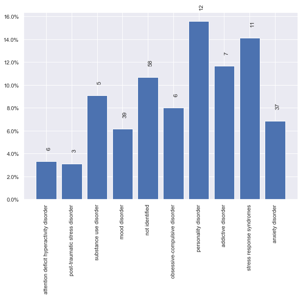

```
total: 85
```

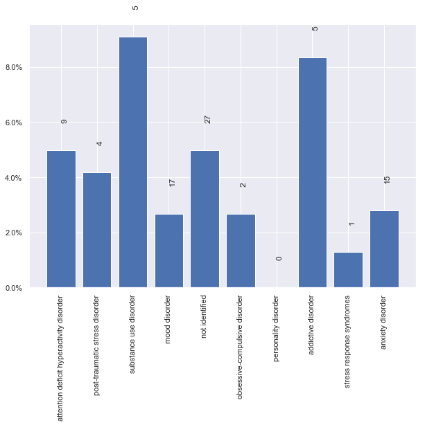

```
total: 180
```

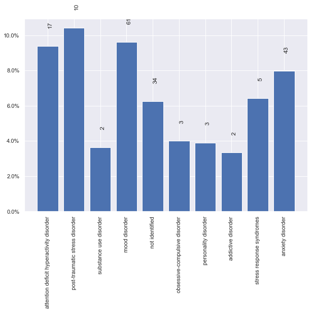

```
total: 124
```

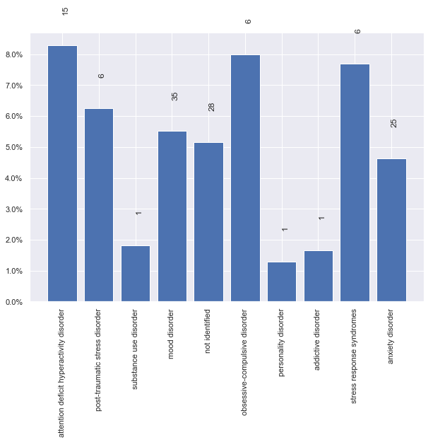

```
total: 339
```

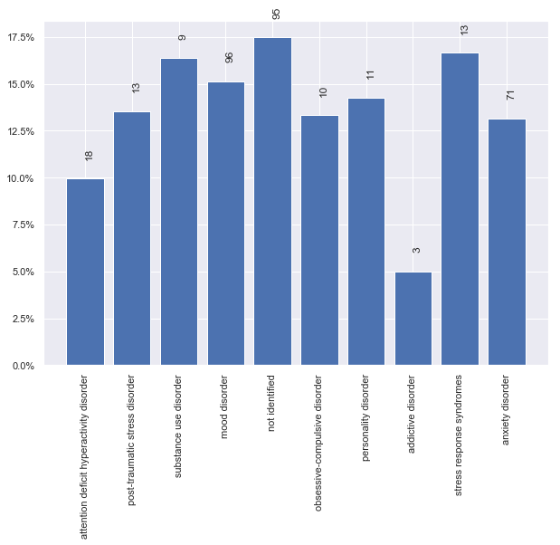

```python
analyze_clusters(KMeans(n_clusters=10, random_state=0), cluster_data(above_50_df, 44))
```

#### To investigate, we visualise people with disorders in 2D space using PCA and LDA

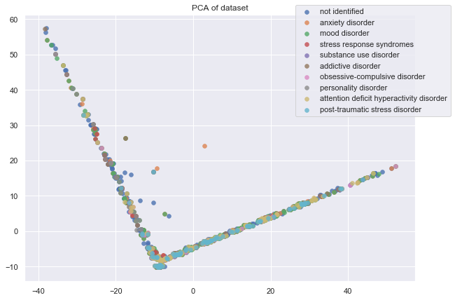

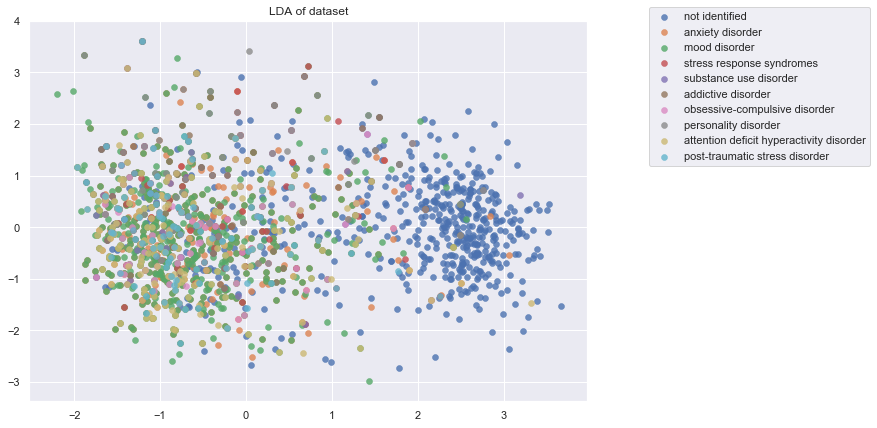

```python
from sklearn.discriminant_analysis import LinearDiscriminantAnalysis
from sklearn.decomposition import PCA

X1 = above_50_df[[col for col in above_50_df if col not in ['Q48','Q49']]]
y1 = above_50_df["Q49"]

lda = LinearDiscriminantAnalysis(n_components=2)
X_r2 = lda.fit(X1, y1).transform(X1)

pca = PCA(n_components=2)
X_r = pca.fit(X1).transform(X1)

target_names = above_50_df["Q49"].unique()
lw = 0.5

for i, target_name in zip(above_50_df["Q49"].unique(), target_names):
    plt.scatter(X_r[y1 == i, 0], X_r[y1 == i, 1], alpha=.8,
                label=target_name, lw=lw)
plt.legend(bbox_to_anchor=(1.1, 1.05), shadow=False)
plt.title('PCA of dataset')
plt.show()

for i, target_name in zip(above_50_df["Q49"].unique(), target_names):
    plt.scatter(X_r2[y1 == i, 0], X_r2[y1 == i, 1], alpha=.8,
                label=target_name, lw=lw)
plt.legend(bbox_to_anchor=(1.1, 1.05), shadow=False)
plt.title('LDA of dataset')
plt.show()
```

### Conclusion

Problem seems to be hardly divided into clusters by unsupervised learning methods. Disorders seems to be distribued evenly across all clusters. Nature of human psychology, small number of data, many questions answered only by part of people in the survey leads to huge difficulty for unsupervised clustering.

## 3. Final Comments and Conclusions

The dataset is very diverse. Many questions were not asked to certain group of people.

In supervised learning, our strategy was not to drop any record and try to predict mental illness using general answers. We managed to achive around 70% prediction accuracy, which is quite satisfying considering 3 possible outcomes ('No','Maybe','Yes').

We analyzed if the instance suffers under a mental disorder or not and we got 5 rules, where we can see that the in every of these instances the person had a mental disorder in the past (Q47).

The problem seems to be hardly divided into clusters by unsupervised learning methods.